# Machine Learning Course Project

KF

May 18, 2016

## Introduction

Using Machine Learning modeling techniques I can predict with a sufficent amount of accuracy the ‘workout error’ or ‘classe’ in the different exercises tracked by the ‘Wearable Computing: Accerlerometers’ Data Classification of Body Postures and Movements’ by Ugulino, Cardador, Vega, Velloso, Milidiu and Fuks.

## Process

The process I followed was pretty iterative. At many points I would find an additional variable that could be thrown out, or way that the data needed to be cleaned.

1. Read and store the data from https://d396qusza40orc.cloudfront.net/predmachlearn/pml-training.csv
2. Use cross-validation by creating a test data from the train data. I selected a .75/.25 train vs testing size breakdown.
3. Explore and clean the data
   - Remove those that have zero variance.
   - Look for strongly correlated variables to determine if one of the two can be removed from the dataset
4. Test out machine learning models.
   - Once a model is found that is of acceptable accuracy, apply it to the test data set created in Step 2 to ensure that you didn’t overfit.
5. Apply the model to the dataset where the classe is unknown and to be predicted.

#### 1. Read data. An important step here was to account for special na.values by setting na.string = c(“.”,“#DIV/0!”, “”, “NA”)

#### 2. Cross-Validation

```r
inTrain <- createDataPartition(y = train$classe, p = 0.75, list = FALSE)
train <- train[inTrain,]
validation <- train[-inTrain,]
```

#### 3. Highlights of Data Cleaning

First, I got a feel for the data with basic summary functions

```r
names(train)
str(train)
```

After looking through the data, I decided to remove the first 7 columns and all columns with NA in the first row.

```r
train1 <- train[,8:160]
NAflag <- train1[1,]
NAflag2 <- !is.na(NAflag)
train2 <- train1[,NAflag2]
```

I also chesked from variables with near zero variance, but discovered those had already been removed by my NA cleaning.

```r
nsv <- nearZeroVar(train2, saveMetrics = TRUE)
head(nsv)
```

```
##                  freqRatio percentUnique zeroVar   nzv
## roll_belt         1.135747     7.6504960   FALSE FALSE
## pitch_belt        1.019737    11.6320152   FALSE FALSE
## yaw_belt          1.034121    12.4269602   FALSE FALSE
## total_accel_belt  1.048377     0.1970376   FALSE FALSE
## gyros_belt_x      1.020329     0.8493002   FALSE FALSE
## gyros_belt_y      1.121967     0.4348417   FALSE FALSE
```

Correlation Analysis: I looked for variables with correlation > 0.95, then plotted them against each other to see which seemed to be a better predictor of classe.

```
##                  row col
## total_accel_belt   4   1
## accel_belt_z      10   1
## accel_belt_x       8   2
## roll_belt          1   4
## accel_belt_z      10   4
## pitch_belt         2   8
## roll_belt          1  10
## total_accel_belt   4  10
## gyros_dumbbell_z  33  31
## gyros_dumbbell_x  31  33
```

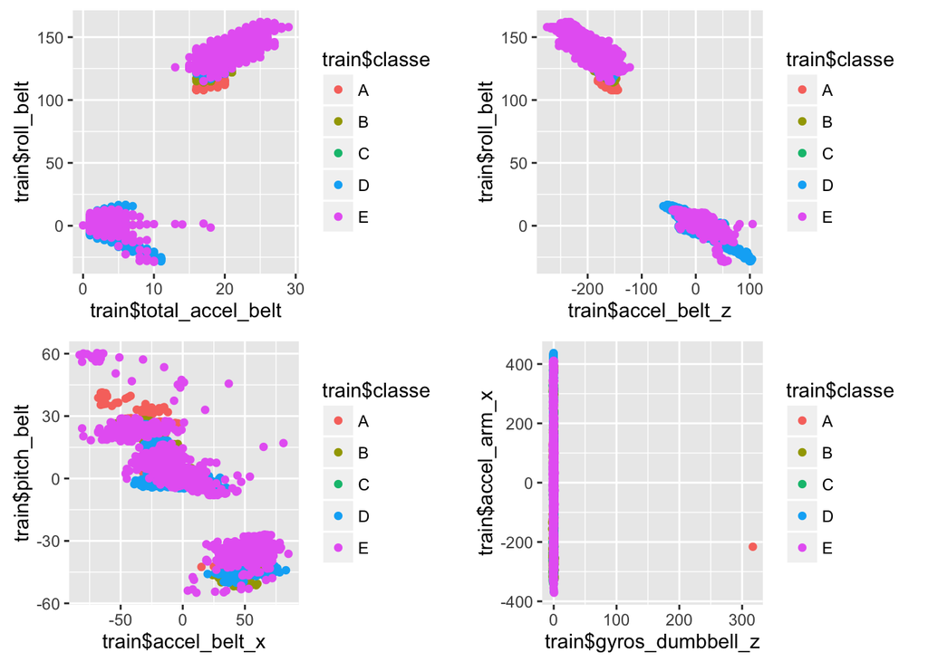

Findings from looking at correlations: kick out total_accel_belt, accel_belt_z, accel_belt_x because they have another highly correlated variable that looks to be better in predicting class. Kick out gyros_dumbbell_z because of the extreme outlier.

#### 4. Test different model fit methods.

Tree prediction with ‘rpart’ was not accurate enough

Even though running a random forest model fit took a long time, it gave me the results I hoped for.

```r
knitr::opts_chunk$set(cache=TRUE)
m <- train(classe~ . , method = "rf", preProcess = c("center", "scale"), data = train3)
pred <- predict(m, train3)
confusionMatrix(pred, train3$classe)
```

```
## Confusion Matrix and Statistics
##
##           Reference
## Prediction    A    B    C    D    E
##          A 4185    0    0    0    0
##          B    0 2848    0    0    0
##          C    0    0 2567    0    0
##          D    0    0    0 2412    0
##          E    0    0    0    0 2706
##
## Overall Statistics
##
##                Accuracy : 1
##                  95% CI : (0.9997, 1)
##     No Information Rate : 0.2843
##     P-Value [Acc > NIR] : < 2.2e-16
##
##                   Kappa : 1
##  Mcnemar's Test P-Value : NA
##
## Statistics by Class:
##
##                      Class: A Class: B Class: C Class: D Class: E
## Sensitivity            1.0000   1.0000   1.0000   1.0000   1.0000
## Specificity            1.0000   1.0000   1.0000   1.0000   1.0000
## Pos Pred Value         1.0000   1.0000   1.0000   1.0000   1.0000
## Neg Pred Value         1.0000   1.0000   1.0000   1.0000   1.0000
## Prevalence             0.2843   0.1935   0.1744   0.1639   0.1839
## Detection Rate         0.2843   0.1935   0.1744   0.1639   0.1839
## Detection Prevalence   0.2843   0.1935   0.1744   0.1639   0.1839
## Balanced Accuracy      1.0000   1.0000   1.0000   1.0000   1.0000
```

```r
pred <- predict(m, validation)
confusionMatrix(pred, validation$classe)
```

```
## Confusion Matrix and Statistics
##
##           Reference
## Prediction    A    B    C    D    E
##          A 1066    0    0    0    0
##          B    0  693    0    0    0
##          C    0    0  647    0    0
##          D    0    0    0  584    0
##          E    0    0    0    0  697
##
## Overall Statistics
##
##                Accuracy : 1
##                  95% CI : (0.999, 1)
##     No Information Rate : 0.2891
##     P-Value [Acc > NIR] : < 2.2e-16
##
##                   Kappa : 1
##  Mcnemar's Test P-Value : NA
##
## Statistics by Class:
##
##                      Class: A Class: B Class: C Class: D Class: E
## Sensitivity            1.0000    1.000   1.0000   1.0000    1.000
## Specificity            1.0000    1.000   1.0000   1.0000    1.000
## Pos Pred Value         1.0000    1.000   1.0000   1.0000    1.000
## Neg Pred Value         1.0000    1.000   1.0000   1.0000    1.000
## Prevalence             0.2891    0.188   0.1755   0.1584    0.189
## Detection Rate         0.2891    0.188   0.1755   0.1584    0.189
## Detection Prevalence   0.2891    0.188   0.1755   0.1584    0.189
## Balanced Accuracy      1.0000    1.000   1.0000   1.0000    1.000
```

#### 5. Apply it to the test data to determine the final predicted results

```r
predict(m, test)
```

```
##  [1] B A B A A E D B A A B C B A E E A B B B
## Levels: A B C D E
```

## Conclusion

#### The Use of Cross Validation

I used a 0.75 vs. 0.25 ratio to partition my test and training datasets.

#### Other Decision Points

- I didn’t use PCA because this was a scenario where I knew a linear would not make sense
- Manipulate was useful to quickly filter through a lot of plots to try to better understand the predictor relationships